# Practical Machine Learning Final Project

Charlie Towner

January 16, 2017

## PRACTICAL MACHINE LEARNING FINAL COURSE PROJECT

## Background:

## Using devices such as Jawbone Up, Nike FuelBand, and Fitbit it is now possible to collect a large amount of data about personal activity relatively

## inexpensively. These type of devices are part of the quantified self movement - a group of enthusiasts who take measurements about themselves regularly

## to improve their health, to find patterns in their behavior, or because they are tech geeks. One thing that people regularly do is quantify how much of

## a particular activity they do, but they rarely quantify how well they do it. In this project, your goal will be to use data from accelerometers on the

## belt, forearm, arm, and dumbell of 6 participants. They were asked to perform barbell lifts correctly and incorrectly in 5 different ways. More

## information is available from the website here: http://groupware.les.inf.puc-rio.br/har (see the section on the Weight Lifting Exercise Dataset).

## The training data for this project are available here: https://d396qusza40orc.cloudfront.net/predmachlearn/pml-training.csv

## The test data are available here: https://d396qusza40orc.cloudfront.net/predmachlearn/pml-testing.csv

## The goal of the project is to create a predictive model that will predict the outcome of a bicep curl exercise based on ~ 155-160

## recorded measurements taken from recording devices on a belt, forearm, upper arm, and dumbbell. The data was provided in 2 files: a

## training file of ~ 19,600 records and a test file of 20 records.

## The outcome class can have one of 5 values:

## A - Exercise executed correctly

## B - Throwing the elbows to the front

## C - Lifting the dumbbell only halfway

## D - Lowering the dumbbell only halfway

## E - Throwing the hips forward

## First Step: Get the data loaded:

```r
training <- read.csv("C:/Coursera/Practical_ML/fnlproj/pml-training.csv", stringsAsFactors = FALSE)
testing <- read.csv("C:/Coursera/Practical_ML/fnlproj/pml-testing.csv", stringsAsFactors = FALSE  )
set.seed(3423)
```

# Check the training dataset for zero or near-zero variance. Display the metrics. Then remove the variables that are near-zero variance. This will print the

# list of near-zero variables

```r
require(caret)
nzm_toprint <- nearZeroVar(training, saveMetrics=TRUE)
nzm_toprint
```

```
##                            freqRatio percentUnique zeroVar   nzv
## X                           1.000000  100.00000000   FALSE FALSE
## user_name                   1.100679    0.03057792   FALSE FALSE
## raw_timestamp_part_1        1.000000    4.26562022   FALSE FALSE
## raw_timestamp_part_2        1.000000   85.53154622   FALSE FALSE
## cvtd_timestamp              1.000668    0.10192641   FALSE FALSE
## new_window                 47.330049    0.01019264   FALSE  TRUE
## num_window                  1.000000    4.37264295   FALSE FALSE
## roll_belt                   1.101904    6.77810621   FALSE FALSE
## pitch_belt                  1.036082    9.37722964   FALSE FALSE
## yaw_belt                    1.058480    9.97349913   FALSE FALSE
## total_accel_belt            1.063160    0.14779329   FALSE FALSE
## kurtosis_roll_belt       1921.600000    2.02323922   FALSE  TRUE
## kurtosis_picth_belt       600.500000    1.61553358   FALSE  TRUE
## kurtosis_yaw_belt          47.330049    0.01019264   FALSE  TRUE
## skewness_roll_belt       2135.111111    2.01304658   FALSE  TRUE
## skewness_roll_belt.1      600.500000    1.72255631   FALSE  TRUE
## skewness_yaw_belt          47.330049    0.01019264   FALSE  TRUE
## max_roll_belt               1.000000    0.99378249   FALSE FALSE
## max_picth_belt              1.538462    0.11211905   FALSE FALSE
## max_yaw_belt              640.533333    0.34654979   FALSE  TRUE
## min_roll_belt               1.000000    0.93772296   FALSE FALSE
## min_pitch_belt              2.192308    0.08154113   FALSE FALSE
## min_yaw_belt              640.533333    0.34654979   FALSE  TRUE
## amplitude_roll_belt         1.290323    0.75425543   FALSE FALSE
## amplitude_pitch_belt        3.042254    0.06625217   FALSE FALSE
## amplitude_yaw_belt         50.041667    0.02038528   FALSE  TRUE
## var_total_accel_belt        1.426829    0.33126083   FALSE FALSE
## avg_roll_belt               1.066667    0.97339721   FALSE FALSE
## stddev_roll_belt            1.039216    0.35164611   FALSE FALSE
## var_roll_belt               1.615385    0.48924676   FALSE FALSE
## avg_pitch_belt              1.375000    1.09061258   FALSE FALSE
## stddev_pitch_belt           1.161290    0.21914178   FALSE FALSE
## var_pitch_belt              1.307692    0.32106819   FALSE FALSE
## avg_yaw_belt                1.200000    1.22311691   FALSE FALSE
## stddev_yaw_belt             1.693878    0.29558659   FALSE FALSE
## var_yaw_belt                1.500000    0.73896647   FALSE FALSE
## gyros_belt_x                1.058651    0.71348486   FALSE FALSE
## gyros_belt_y                1.144000    0.35164611   FALSE FALSE
## gyros_belt_z                1.066214    0.86127816   FALSE FALSE
```

[output cut: 106 more lines]

```
## stddev_pitch_forearm       41.500000    1.64611151   FALSE  TRUE
## var_pitch_forearm          83.000000    1.65120783   FALSE  TRUE
## avg_yaw_forearm            83.000000    1.65120783   FALSE  TRUE
## stddev_yaw_forearm         85.000000    1.64101519   FALSE  TRUE
## var_yaw_forearm            85.000000    1.64101519   FALSE  TRUE
## gyros_forearm_x             1.059273    1.51870350   FALSE FALSE
## gyros_forearm_y             1.036554    3.77637346   FALSE FALSE
## gyros_forearm_z             1.122917    1.56457038   FALSE FALSE
## accel_forearm_x             1.126437    4.04647844   FALSE FALSE
## accel_forearm_y             1.059406    5.11160942   FALSE FALSE
## accel_forearm_z             1.006250    2.95586586   FALSE FALSE
## magnet_forearm_x            1.012346    7.76679238   FALSE FALSE
## magnet_forearm_y            1.246914    9.54031189   FALSE FALSE
## magnet_forearm_z            1.000000    8.57710733   FALSE FALSE
## classe                      1.469581    0.02548160   FALSE FALSE
```

```r
nzm <- nearZeroVar(training)
train_nzv_rmvd <- training[,-nzm]
```

# Get the total # of records in the training dataset

```r
require(dplyr)
totrecs <- count(train_nzv_rmvd)[[1]]
```

# This block removes any column that has NA for > 95% of the records

```r
cols_na <- apply(train_nzv_rmvd, 2, function(x) {ifelse(sum(is.na(x))/totrecs>0.95,TRUE,FALSE)})
cols_rmv <- which(cols_na==TRUE)
train_fnl <- train_nzv_rmvd[,-cols_rmv]

train_fnl <- select(train_fnl, -starts_with("raw_time"))
train_fnl <- select(train_fnl, -X, -cvtd_timestamp)
train_fnl <- select(train_fnl, classe, everything())
```

# Split the training and test data; 2 comments: I realize that decision tree methodologies aren’t sensitive to large variations in numeric scale so scaling/

# centering is not required. However, I believe the results show that it doesn’t necessarily hurt either, in this case. I intend to run this unscaled &

# uncentered as well. I want to have a scaled version to apply some other methods to that are sensitive to differences in scale. Comment 2: I used K Nearest

# Neighbor imputing to fill in missing variables, although there were few.

```r
inTrain <- createDataPartition(y=train_fnl$classe,p=0.7, list=FALSE)
ss_train <- train_fnl[inTrain,]
ss_test <- train_fnl[-inTrain,]
preproc_ss <- preProcess(ss_train,method="knnImpute")
nsimp_ss_train <- predict(preproc_ss,ss_train)
nsimp_ss_test <- predict(preproc_ss,ss_test)
```

# Random Forest algorithm using 10-fold cross-validation

```r
cntrl <- trainControl(method="cv",number=10)
RFfitcv <- train(nsimp_ss_train[,c(3:55)],nsimp_ss_train[,1],data=nsimp_ss_train,method="rf", trControl=cntrl)
RFfitcv$finalModel
```

```
##
## Call:
##  randomForest(x = x, y = y, mtry = param$mtry, data = ..1)
##                Type of random forest: classification
##                      Number of trees: 500
## No. of variables tried at each split: 27
##
##         OOB estimate of  error rate: 0.28%
## Confusion matrix:
##      A    B    C    D    E  class.error
## A 3904    1    0    0    1 0.0005120328
## B    9 2645    4    0    0 0.0048908954
## C    0    6 2389    1    0 0.0029215359
## D    0    0   11 2241    0 0.0048845471
## E    0    0    0    6 2519 0.0023762376
```

# Use the model on the validation test data.

```r
pred_RFcv <- predict(RFfitcv,nsimp_ss_test)
ConfMat_RF <- confusionMatrix(pred_RFcv, nsimp_ss_test$classe)
```

# Display the Confusion Matrix output & the Bar Chart of the accuracy by class for the Random Forest Method

```r
ConfMat_RF
```

```
## Confusion Matrix and Statistics
##
##           Reference
## Prediction    A    B    C    D    E
##          A 1674    1    0    0    0
##          B    0 1137    3    0    0
##          C    0    1 1023    2    0
##          D    0    0    0  961    1
##          E    0    0    0    1 1081
##
## Overall Statistics
##
##                Accuracy : 0.9985
##                  95% CI : (0.9971, 0.9993)
##     No Information Rate : 0.2845
##     P-Value [Acc > NIR] : < 2.2e-16
##
##                   Kappa : 0.9981
##  Mcnemar's Test P-Value : NA
##
## Statistics by Class:
##
##                      Class: A Class: B Class: C Class: D Class: E
## Sensitivity            1.0000   0.9982   0.9971   0.9969   0.9991
## Specificity            0.9998   0.9994   0.9994   0.9998   0.9998
## Pos Pred Value         0.9994   0.9974   0.9971   0.9990   0.9991
## Neg Pred Value         1.0000   0.9996   0.9994   0.9994   0.9998
## Prevalence             0.2845   0.1935   0.1743   0.1638   0.1839
## Detection Rate         0.2845   0.1932   0.1738   0.1633   0.1837
## Detection Prevalence   0.2846   0.1937   0.1743   0.1635   0.1839
## Balanced Accuracy      0.9999   0.9988   0.9982   0.9983   0.9994
```

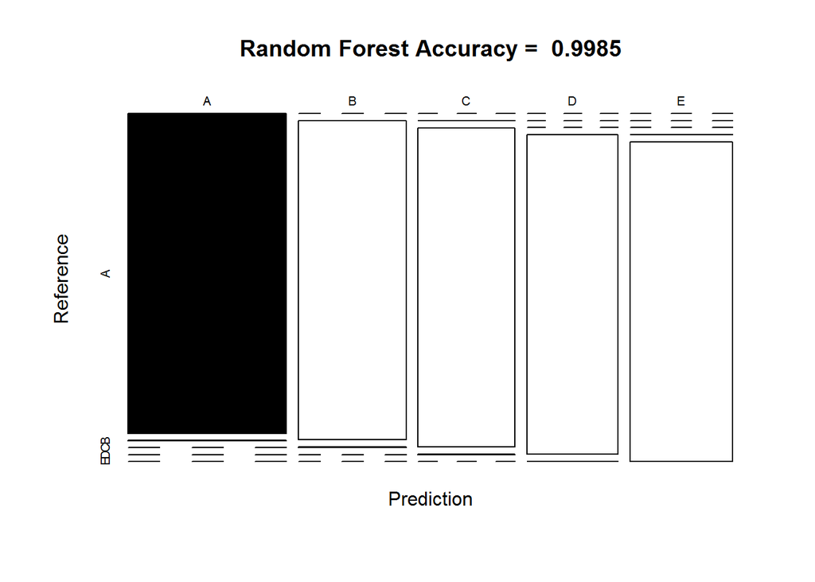

```r
plot(ConfMat_RF$table, col=ConfMat_RF$byClass, main = paste("Random Forest Accuracy = ", round(ConfMat_RF$overall['Accuracy'], 4)))
```

# Generalized Boosted Model

```r
library(gbm)
library(plyr)
library(splines2)
GBMfitcv <- train(classe~.,data=nsimp_ss_train,method="gbm", trControl=cntrl)
GBMfitcv$finalModel
```

```
## A gradient boosted model with multinomial loss function.
## 150 iterations were performed.
## There were 58 predictors of which 45 had non-zero influence.
```

```r
pred_GBMcv <- predict(GBMfitcv,nsimp_ss_test)
ConfMat_GBM <- confusionMatrix(pred_GBMcv, nsimp_ss_test$classe)
```

# Display the Confusion Matrix output & the Bar Chart of the accuracy by class for the Boosted Method

```r
ConfMat_GBM
```

```
## Confusion Matrix and Statistics
##
##           Reference
## Prediction    A    B    C    D    E
##          A 1668    6    0    2    0
##          B    4 1124   11    7    4
##          C    0    9 1013   12    4
##          D    2    0    2  942   16
##          E    0    0    0    1 1058
##
## Overall Statistics
##
##                Accuracy : 0.9864
##                  95% CI : (0.9831, 0.9892)
##     No Information Rate : 0.2845
##     P-Value [Acc > NIR] : < 2.2e-16
##
##                   Kappa : 0.9828
##  Mcnemar's Test P-Value : NA
##
## Statistics by Class:
##
##                      Class: A Class: B Class: C Class: D Class: E
## Sensitivity            0.9964   0.9868   0.9873   0.9772   0.9778
## Specificity            0.9981   0.9945   0.9949   0.9959   0.9998
## Pos Pred Value         0.9952   0.9774   0.9759   0.9792   0.9991
## Neg Pred Value         0.9986   0.9968   0.9973   0.9955   0.9950
## Prevalence             0.2845   0.1935   0.1743   0.1638   0.1839
## Detection Rate         0.2834   0.1910   0.1721   0.1601   0.1798
## Detection Prevalence   0.2848   0.1954   0.1764   0.1635   0.1799
## Balanced Accuracy      0.9973   0.9907   0.9911   0.9866   0.9888
```

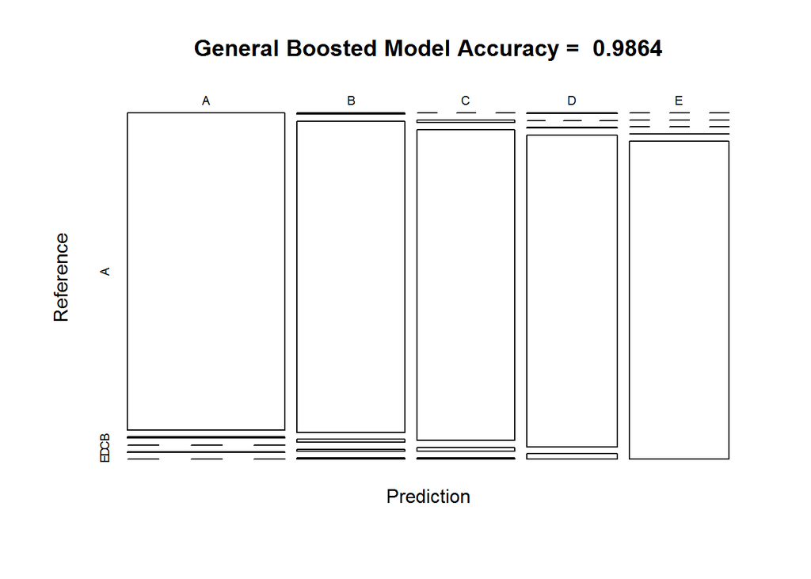

```r
plot(ConfMat_GBM$table, col=ConfMat_GBM$byClass, main = paste("General Boosted Model Accuracy = ", round(ConfMat_GBM$overall['Accuracy'], 4)))
```

# Run the model on the test data on the Random Forest Model after removing the variables that were removed in the training data & applying the pre-

# processing modifications. The out-of-sample error rate is 0.0015.

```r
test_nzv_rmvd <- testing[,-nzm]
test_fnl <- test_nzv_rmvd[,-cols_rmv]

test_fnl <- select(test_fnl, -starts_with("raw_time"))
test_fnl <- select(test_fnl, -X, -cvtd_timestamp)
preproc_test <- predict(preproc_ss,test_fnl)
test_pred <- predict(RFfitcv, newdata=preproc_test)
test_pred
```

```
##  [1] B A B A A E D B A A B C B A E E A B B B
## Levels: A B C D E
```